# Grouping dissemination areas into Vancouver neighbourhoods

Andrew McCormack

## Why even do this?

Good question.

I want to find out about different characteristics of Vancouver’s neighbourhoods with data from the [2021 Canadian census](https://www12.statcan.gc.ca/census-recensement/index-eng.cfm).

The problem is that there is no “Vancouver Neighbourhoods” option in the StatCan census profile data. However, I can access census profile characteristics for each census dissemination area (DA), which are much smaller than neighbourhoods. So **my goal here is to find out which DAs belong to which Vancouver neighbourhoods, group these DAs together, and aggregate census profile characteristics to the Vancouver neighbourhood level.**

The City of Vancouver has very comprehensive and nicely designed neighbourhood profiles (like [this one](https://vancouver.ca/files/cov/social-indicators-profile-killarney.pdf) for Killarney), but I can’t find any that are updated with new data from 2021 census. My assumption is that in order to get these data (for 2016), someone at City Hall either (a) had access to StatCan microdata and was able to create custom geographies for Vancouver’s neighbourhoods, or (b) they’re grouping census dissemination areas into neighbourhoods. Realtors also have a lot of census information up their sleeves, but this seems to typically be at the DA level, and I’m afraid to contact them because then they might try to sell me a house. In any case, all I have access to is census dissemination areas.

As we’ll see below the *vast majority* of DAs in the Vancouver area neatly align with Vancouver’s neighbourhoods without overlapping, allowing us to accurately estimate neighbourhood-level data (e.g. population) by summing up the tract-level information.

Let’s get started.

## Loading packages

```r
library(sf)
library(tidyverse)
library(Hmisc)
library(viridis)
library(data.table)
library(xml2)
library(httr)
library(glue)
library(ggtext)
library(kableExtra)

maptheme <- theme_void() +
  theme(text = element_text(family = "IBM Plex Sans"),
        legend.position = "bottom",
        legend.title = element_blank(),
        plot.background = element_rect(fill = "#F5F4F2"),
        panel.background = element_rect(fill = "#F5F4F2"),
        plot.title = element_text(face = "bold"))
```

## Reading in shapefiles

We’ll need a shapefile of all the census dissemination areas, as well as a shapefile of Vancouver’s neighbourhoods, The former I’ve downloaded from [StatCan](https://www12.statcan.gc.ca/census-recensement/2021/geo/sip-pis/boundary-limites/index2021-eng.cfm?year=21) and the latter I’ve downloaded from the [City of Vancouver’s Open Data Portal](https://opendata.vancouver.ca/explore/dataset/local-area-boundary/information/?disjunctive.name).

The DA shapefile is pretty big, so off the bat I narrow it down to only include the bounding box of Vancouver (based off of the Vancouver shapefile).

```r
# Read in DA shapefile
cda <- st_read("lda_000b21a_e/lda_000b21a_e.shp")

# Read in YVR neighbourhoods shapefile
van <- st_read("local-area-boundary/local-area-boundary.shp")

# Convert YVR shafefile CRS to be the same as the cda CRS
van <- st_transform(van, st_crs(cda))

# Crop DA shapefile to include be within the borders of Vancouver
cda_van <- st_crop(cda, st_bbox(van))
```

Let’s overlay both maps on top of one another take a quick look at what we’re working with:

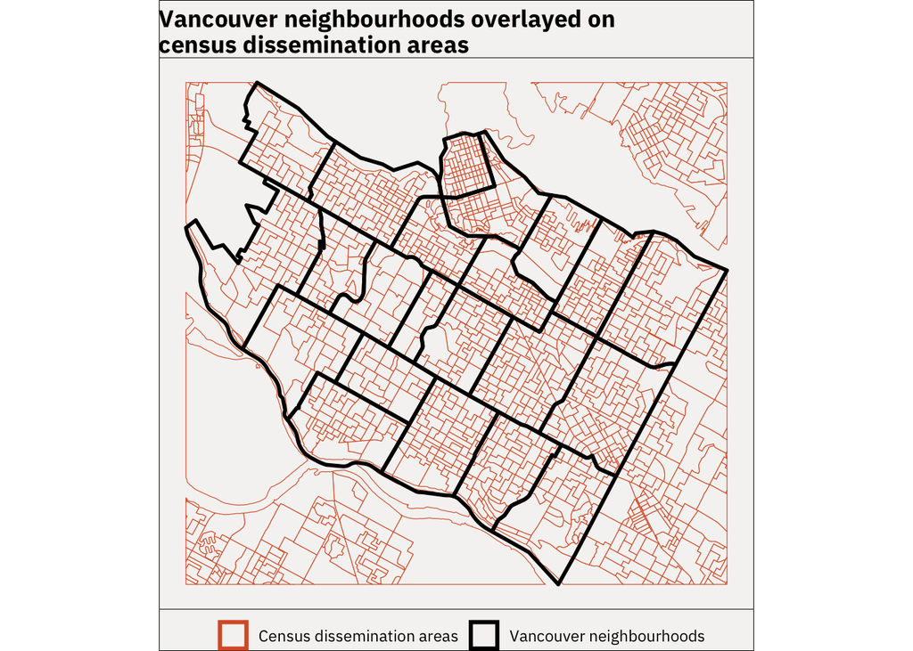

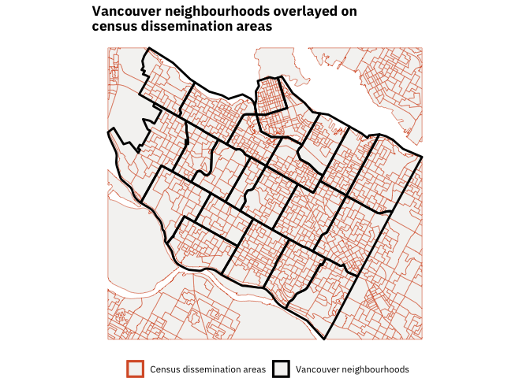

Vancouver neighbourhoods overlayed on census dissemination areas

```r
ggplot(cda_van) +
  geom_sf(aes(colour = "Census dissemination areas"),
          fill = "#f5f4f2") +
  geom_sf(data = van,
          aes(colour = "Vancouver neighbourhoods"),
          fill = NA,
          linewidth = 1) +
  scale_colour_manual(values = c("#D95E32", "black")) +
  ggtitle(str_wrap("Vancouver neighbourhoods overlayed on census dissemination areas", 40)) +
  maptheme
```

It’s hard to tell at this point, but we can already tell we’ll be able to come up with decent DA-to-neighbourhood groupings.

## Determining DA-Vancouver neighbourhood overlap

Next we’ll get the intersections of the DAs and Vancouver neighbourhoods. That is we’ll find out which Vancouver neighbourhood(s) each DA overlaps with. We’ll also calculate the area of each intersection.

```r
cda_intersections <- st_intersection(van, cda_van) %>%
  mutate(intersect_area = st_area(.)) %>%
  tibble() %>%
  dplyr::select(name, DAUID, intersect_area, -geometry)

# Take a quick look
cda_intersections %>%
  arrange(desc(DAUID)) %>%
  head() %>%
  mutate(intersect_area = round(intersect_area))
```

```
## # A tibble: 6 × 3
##   name                     DAUID    intersect_area
##   <chr>                    <chr>             [m^2]
## 1 Kensington-Cedar Cottage 59154196             27
## 2 Renfrew-Collingwood      59154196         143291
## 3 Killarney                59154195         120619
## 4 Renfrew-Collingwood      59154195           2943
## 5 Victoria-Fraserview      59154195            427
## 6 Killarney                59154194            173
```

Looking at a few rows of our intersections, we can see CD `59154196` (a DA I’m sure we’re all familiar with) is mostly in Renfrew-Collignwood, but not all of it — 27 square meters are in Kensington Cedar Cottage. Nonetheless, based on the fact that 99.98% of CD `59154196` is in Renfrew-Collingwood, we’ll go out on a limb and call this a Renfrew-Collingwood CD.

Let’s apply this analysis more broadly and get the areas of all the DAs, then divide each DA-Vancouver neighbourhood intersections by the DA’s total area.

```r
cda_intersections <- cda_intersections %>%
  mutate(prop_of_da = intersect_area/sum(intersect_area),
         .by = DAUID)

# Named vector to rename 1, 2, 3 into 0-10%, 10-20%, 20-30%, etc.
bucket_labels <- setNames(paste0(seq(0, 0.9, 0.1) * 100, "-",
                seq(0, 0.9, 0.1) * 100 + 10, "%"),
                1:10)

# Create some labels for the intervals

# Group into 10% buckets
cda_intersections <- cda_intersections %>%
  mutate(prop_of_da_buckets = cut(prop_of_da,
                                  breaks = seq(0, 1, 0.1),
                                  include.lowest = TRUE))
```

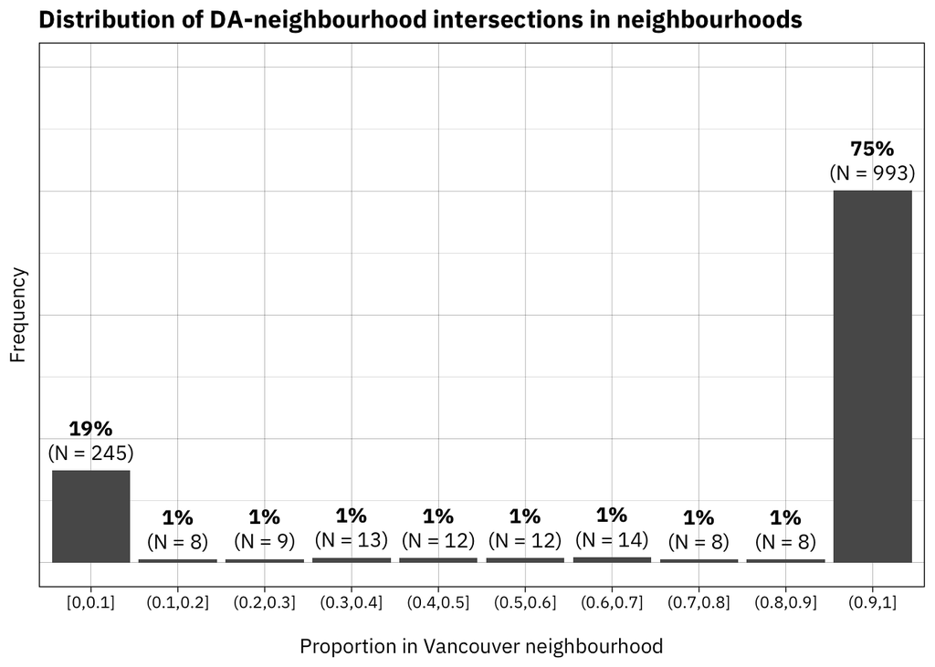

```r
cda_intersections %>%
  count(prop_of_da_buckets) %>%
  mutate(proportion = n/sum(n)) %>%
  ggplot(aes(prop_of_da_buckets, proportion)) +
  geom_col() +
  scale_y_continuous(limits = c(0, 1)) +
  geom_richtext(aes(label = glue("**{round(proportion*100)}%**<br>(N = {n})")),
                family = "IBM Plex Sans",
                vjust = 0, fill = NA, label.color = NA) +
  theme_linedraw() +
  labs(x = "\nProportion in Vancouver neighbourhood",
       y = "Frequency",
       title = "Distribution of DA-neighbourhood intersections in neighbourhoods") +
  theme(text = element_text(family = "IBM Plex Sans"),
          axis.text.y = element_blank(),
        axis.ticks.y = element_blank(),
        plot.title = element_text(face = "bold"))
```

As we can see, for 75% of the DA-neighbourhood intersections, 90% or more of the area of those intersections belong to one neighbourhood. In most cases, I think this is due to the fact that the Vancouver Shapefile and Census DA Shapefile don’t line up *exactly* after transforming the CRS, which results in tiny little overaps.

To illlustrate further, let’s look at CDs that span more than one neighbourhood. From the map below, it looks like most (but not all) of the overlap is right along the border of the neighbourhoods:

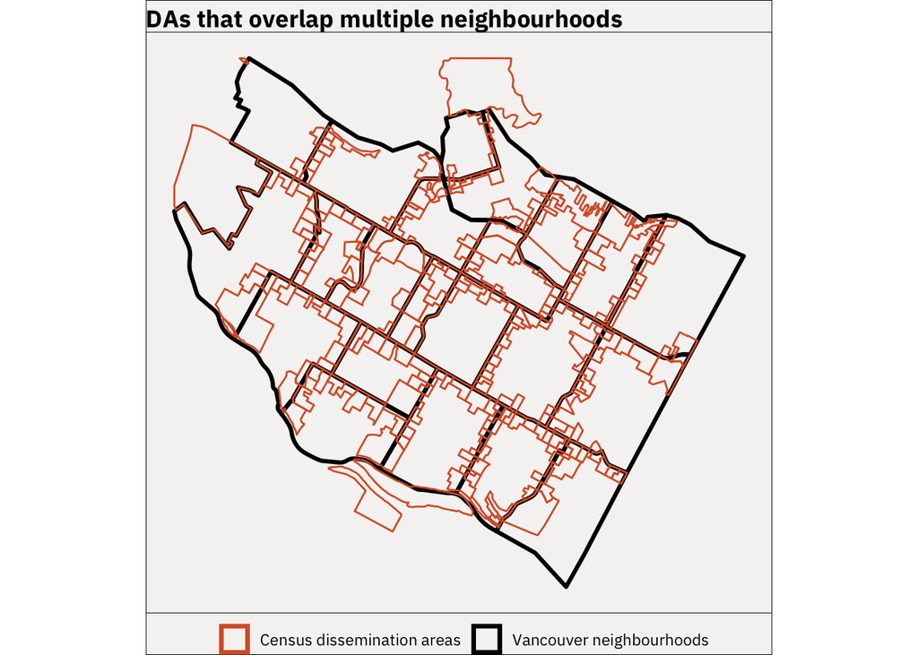

```r
# See which DAUIDs are duplicated. This will be dissemination areas
# that span across 2 or more Vancouver neighbourhoods
duped_DAUIDs <- unique(cda_intersections$DAUID[duplicated(cda_intersections$DAUID)])

# There is some DAs that overlap the borders of some of the Vancouver neighbourhoods.
# The majority of these overlaps appear to be very small. This is something we can
# confirm.
ggplot(cda_van[cda_van$DAUID %in% duped_DAUIDs, ]) +
  geom_sf(data = van,
          aes(colour = "Vancouver neighbourhoods"),
          fill = NA,
          linewidth = 1.1) +
  geom_sf(aes(colour = "Census dissemination areas"),
          alpha = 0.5, fill = NA, linewidth = 0.5) +
  scale_colour_manual(values = c("#D95E32", "black")) +
  theme(legend.position = "none") +
  ggtitle(str_wrap("DAs that overlap multiple neighbourhoods", 40)) +
  theme_void() +
  maptheme
```

### Removing non-Vancouver DAs

If we merge together our DA-neighbourhood intersections with our original DA data, we’ll find there are some `NA` values for the neighbourhoods:

```r
# Next, merge in the intersections
cda_intersections <- left_join(cda_van,
                                      cda_intersections,
                                      by = "DAUID")


head(cda_intersections)
```

```
## Simple feature collection with 6 features and 8 fields
## Geometry type: POLYGON
## Dimension:     XY
## Bounding box:  xmin: 4020076 ymin: 2009464 xmax: 4023738 ymax: 2010531
## Projected CRS: NAD83 / Statistics Canada Lambert
##      DAUID             DGUID LANDAREA PRUID name intersect_area prop_of_da
## 1 59150071 2021S051259150071   1.5073    59 <NA>       NA [m^2]     NA [1]
## 2 59150073 2021S051259150073   0.2620    59 <NA>       NA [m^2]     NA [1]
## 3 59150074 2021S051259150074   0.0658    59 <NA>       NA [m^2]     NA [1]
## 4 59150076 2021S051259150076   0.3286    59 <NA>       NA [m^2]     NA [1]
## 5 59150077 2021S051259150077   0.1138    59 <NA>       NA [m^2]     NA [1]
## 6 59150078 2021S051259150078   0.4834    59 <NA>       NA [m^2]     NA [1]
##   prop_of_da_buckets                       geometry
## 1               <NA> POLYGON ((4022065 2010531, ...
## 2               <NA> POLYGON ((4022672 2010487, ...
## 3               <NA> POLYGON ((4022698 2010531, ...
## 4               <NA> POLYGON ((4022977 2010531, ...
## 5               <NA> POLYGON ((4023360 2010531, ...
## 6               <NA> POLYGON ((4023684 2010371, ...
```

```r
ggplot(cda_intersections[is.na(cda_intersections$name), ]) +
  geom_sf(data = van,
          aes(colour = "Vancouver neighbourhoods"),
          fill = NA,
          linewidth = 1) +
  geom_sf(aes(colour = str_wrap("Census dissemination areas that are not actually in Vancouver", 30)),
          alpha = 0.5, fill = NA, linewidth = 0.5) +
  scale_colour_manual(values = c("#53777A", "black")) +
  theme(legend.position = "none") +
  ggtitle(str_wrap("DAs that are not in Vancouver", 40)) +
  theme_void() +
  maptheme
```

[output not shown]

We can remove these non-Vancouver DAs.

```r
cda_intersections <- cda_intersections[!is.na(cda_intersections$name), ]
```

### Associating each DA with a Vancouver neighbourhood

At this point, we can now associate each CDA with the Vancouver Neighbourhood it belongs to the most:

```r
cda_intersections <- cda_intersections %>%
  group_by(DAUID) %>%
  slice_max(prop_of_da) %>%
  ungroup()
```

Now that we’ve associated each DA with one neighbourhood, we can see if the neighbourhoods we’ve cobbled together from the DAs look anything like the actual Vancouver neighbourhoods.

Because there are so many neighbourhoods, I have to get creative with the colours here:

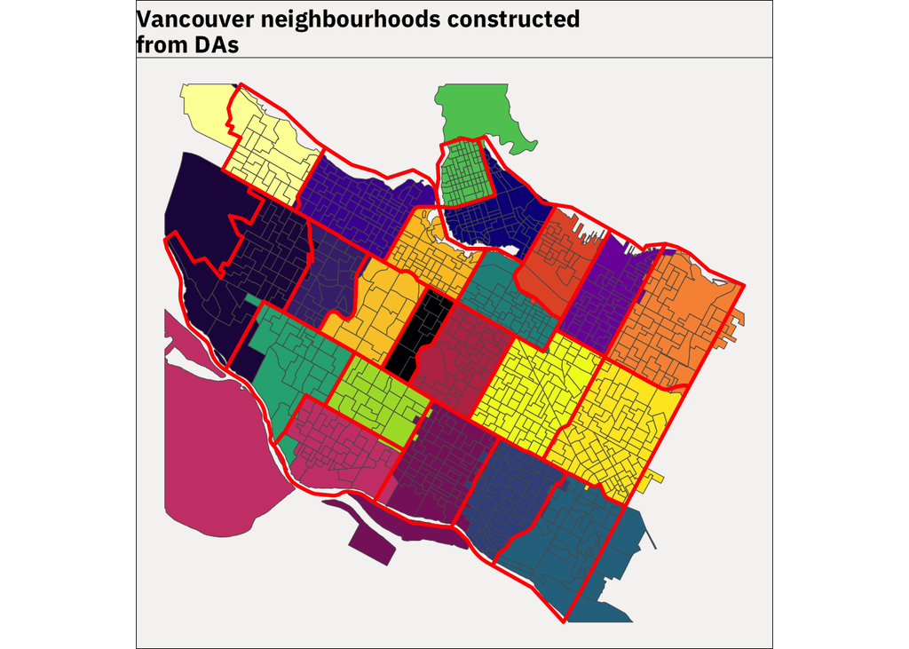

```r
neighbourhood_colours <- sample(c(viridis(9),
                                  inferno(9),
                                  plasma(9)),
                                length(unique(cda_intersections$name)),
                                replace = FALSE)

neighbourhood_colours <- setNames(neighbourhood_colours,
                                  unique(cda_intersections$name))

cda_intersections$name_colour <- recode(cda_intersections$name, !!!neighbourhood_colours)

ggplot(cda_intersections, aes(fill = name_colour)) +
  geom_sf(alpha = 1) +
  geom_sf(data = van, colour = "red", alpha = 0, linewidth = 1, fill = NA) +
  scale_fill_identity() +
  ggtitle(str_wrap("Vancouver neighbourhoods constructed from DAs", 40)) +
  maptheme
```

Not perfect, but looks pretty good overall!

There are some areas that concern us, and will need to be removed: - A large chunk of Sea Island (YVR) that lightly touches Vancouver, and thus is included in the map. There *are* people who live here (in Burkeville) that are not Vancouverites, so let’s remove this CDA. - Mitchell Island (Richmond) and a chunk of Bridgeport (also Richmond). These are mostly industrial areas, so few inhabitants, but let’s remove. - A bunch of Burnaby CDAs along Boundary Road.

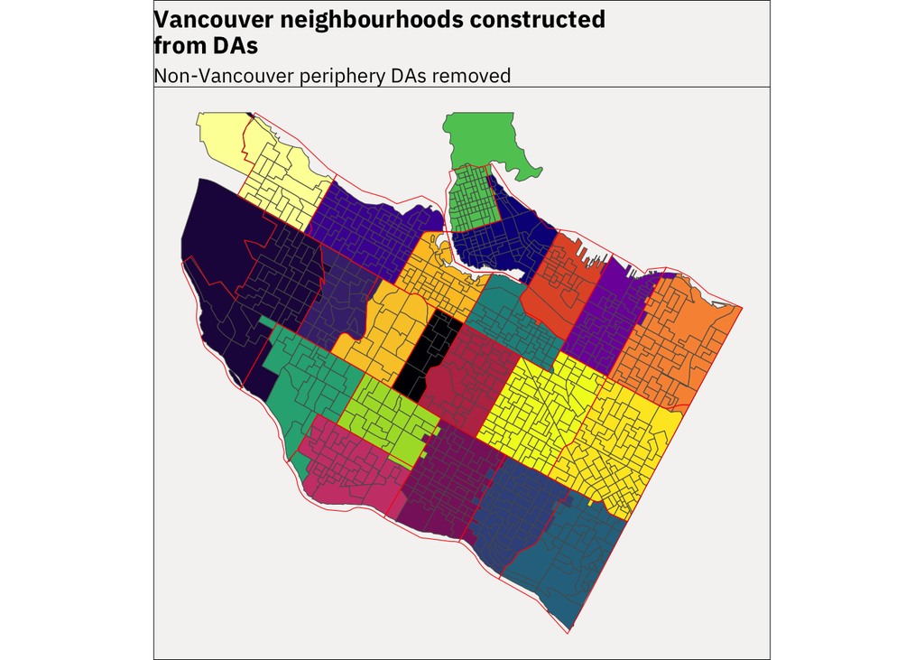

```r
# Manually identify
burnaby_cdas <- c("59150305", "59150314", "59153309", "59153310",
                  "59153311", "59151350", "59151384", "59151232",
                  "59151237", "59151312", "59153633")

sea_island_cdas <- "59153602"
mitchell_island_cdas <- "59151197"

cda_intersections %>%
  filter(!(DAUID %in% c(sea_island_cdas, # Sea Island
                        mitchell_island_cdas, # Mitchell Island/Bridgeport
                        burnaby_cdas))) %>%
  ggplot(aes(fill = name_colour)) +
  geom_sf(alpha = 1) +
  ggtitle(str_wrap("Vancouver neighbourhoods constructed from DAs", 40)) +
  labs(subtitle = "Non-Vancouver periphery DAs removed") +
  geom_sf(data = van, colour = "red", alpha = 0, size = 1, fill = NA) +
  scale_fill_identity() +
  maptheme
```

### Saving our DA to Vancouver neighbourhood mapping

Now that we’re more or less satisfied with how we’ve mapped the DAs to Vancouver neighbourhoods, we can save this mapping and then use it to aggregate the DA Census data.

```r
da_to_neighbourhood <- cda_intersections %>%
  tibble() %>%
  select(DAUID, DGUID, name, -geometry)

head(da_to_neighbourhood)
```

```
## # A tibble: 6 × 3
##   DAUID    DGUID             name
##   <chr>    <chr>             <chr>
## 1 59150305 2021S051259150305 Hastings-Sunrise
## 2 59150307 2021S051259150307 Hastings-Sunrise
## 3 59150308 2021S051259150308 Hastings-Sunrise
## 4 59150309 2021S051259150309 Hastings-Sunrise
## 5 59150310 2021S051259150310 Hastings-Sunrise
## 6 59150311 2021S051259150311 Hastings-Sunrise
```

```r
saveRDS(da_to_neighbourhood, "da_to_neighbourhood.rds")
```